## **Twoing Algoritması - ToothGrowth, mtcars ve Titanic Veri Setleri ile Karşılaştırmalı Analiz**

Twoing (İkileme), karar ağaçlarında kullanılan bir bölünme kriteridir. Gini ve Entropy’den farklı olarak, bir düğüm içindeki saflığı değil, bölünme sonucu oluşan iki alt düğümün birbirinden ne kadar farklı olduğunu ölçer. Yani Twoing, alt düğümlerin sınıf dağılımlarını mümkün olduğunca birbirinden uzaklaştıracak şekilde bölünme yapar. Bu özelliği sayesinde özellikle çok sınıflı problemlerde avantajlıdır, çünkü sınıfları iki gruba ayırarak her bölünmede en iyi ayrımı bulmaya çalışır. Twoing formülü, sol ve sağ düğümlerin büyüklüklerini ve sınıf dağılımları arasındaki farkları dikkate alarak hesaplanır. Pratikte Gini kadar yaygın kullanılmasa da, özellikle sınıfların dengeli dağılmadığı veya çok sayıda sınıf bulunan veri setlerinde başarılı sonuçlar verir. R’da rpart paketinde parms = list(split = “twoing”) parametresi ile kullanılabilir.

```r
options(encoding = "UTF-8")
Sys.setlocale("LC_ALL", "Turkish")
```

```
## [1] "LC_COLLATE=Turkish_Türkiye.1254;LC_CTYPE=Turkish_Türkiye.1254;LC_MONETARY=Turkish_Türkiye.1254;LC_NUMERIC=C;LC_TIME=Turkish_Türkiye.1254"
```

### Bölüm 1-ToothGrowth Veri Seti

ToothGrowth, R içinde hazır olarak bulunan ve C vitamini takviyesinin diş büyümesine etkisini inceleyen bir veri setidir. Bu veri seti, domuz yavrularında farklı C vitamini dozlarının ve kaynaklarının diş uzunluğu üzerindekietkisini ölçmek için yapılan bir deneyin sonuçlarını içerir.

#### 1.1 Gerekli Paketlerin Yüklenmesi

```r
# rpart: Karar ağacı algoritması (Recursive Partitioning)
# rpart.plot: Karar ağacını görselleştirme
# caret: Sınıflandırma ve regresyon için kapsamlı araç seti
library(rpart)
library(rpart.plot)
library(caret)
```

#### 1.2 Veri Setini Yükleme

```r
data(ToothGrowth)
df_tooth <- ToothGrowth
df_tooth$supp <- as.factor(df_tooth$supp)  # Hedef değişkeni faktör yap
```

```r
# Veri yapısını incele
str(df_tooth)
```

```
## 'data.frame':    60 obs. of  3 variables:
##  $ len : num  4.2 11.5 7.3 5.8 6.4 10 11.2 11.2 5.2 7 ...
##  $ supp: Factor w/ 2 levels "OJ","VC": 2 2 2 2 2 2 2 2 2 2 ...
##  $ dose: num  0.5 0.5 0.5 0.5 0.5 0.5 0.5 0.5 0.5 0.5 ...
```

```r
# Verinin ilk 6 satırını görüntüle
head(df_tooth)
```

```
##    len supp dose
## 1  4.2   VC  0.5
## 2 11.5   VC  0.5
## 3  7.3   VC  0.5
## 4  5.8   VC  0.5
## 5  6.4   VC  0.5
## 6 10.0   VC  0.5
```

```r
# Hedef değişken: supp (OJ = Portakal suyu, VC = Askorbik asit)
# supp değişkenini faktör olarak düzenle
df_tooth$supp <- as.factor(df_tooth$supp)
# Hedef değişken dağılımı
table(df_tooth$supp)
```

```
##
## OJ VC
## 30 30
```

```r
# len (diş uzunluğu) ve dose (doz) bağımsız değişkenleri
# len: sayısal, dose: sayısal (0.5, 1.0, 2.0)
summary(df_tooth)
```

```
##       len        supp         dose
##  Min.   : 4.20   OJ:30   Min.   :0.500
##  1st Qu.:13.07   VC:30   1st Qu.:0.500
##  Median :19.25           Median :1.000
##  Mean   :18.81           Mean   :1.167
##  3rd Qu.:25.27           3rd Qu.:2.000
##  Max.   :33.90           Max.   :2.000
```

#### 1.3 Model Kurulumu

```r
set.seed(789)
index <- createDataPartition(df_tooth$supp, p = 0.75, list = FALSE)
train_data <- df_tooth[index, ]
test_data <- df_tooth[-index, ]

cat("\n=== VERİ BÖLÜNME SONUÇLARI ===\n")
```

```
##
## === VERİ BÖLÜNME SONUÇLARI ===
```

```r
cat("Eğitim seti:", nrow(train_data), "gözlem\n")
```

```
## Eğitim seti: 46 gözlem
```

```r
cat("Test seti:", nrow(test_data), "gözlem\n")
```

```
## Test seti: 14 gözlem
```

```r
cat("\nEğitim seti sınıf dağılımı:\n")
```

```
##
## Eğitim seti sınıf dağılımı:
```

```r
table(train_data$supp)
```

```
##
## OJ VC
## 23 23
```

```r
cat("\nTest seti sınıf dağılımı:\n")
```

```
##
## Test seti sınıf dağılımı:
```

```r
table(test_data$supp)
```

```
##
## OJ VC
##  7  7
```

```r
# Cross validation ayarları (sınıflandırma için)
control_class <- trainControl(
method = "cv",                      # Cross validation
number = 5,                         # 5 kat
classProbs = TRUE,                  # Sınıf olasılıklarını hesapla
summaryFunction = twoClassSummary,  # ROC, Sens, Spec hesapla
savePredictions = TRUE
)

# Farklı cp değerleri (grid search)
tune_grid <- expand.grid(cp = c(0.001, 0.005, 0.01, 0.02, 0.05, 0.1))

# Twoing algoritması ile model eğitimi (5-fold CV)
set.seed(789)
model_tooth_twoing <- train(
supp ~ .,                      # Hedef: supp, bağımsız: tüm değişkenler
data = df_tooth,               # Tüm veri seti (CV içinde train/test ayrılacak)
method = "rpart",              # Karar ağacı
trControl = control_class,     # CV ayarları
tuneGrid = tune_grid,          # Farklı cp değerleri
parms = list(split = "twoing") # Bölünme kriteri: TWOING
)
# CV sonuçları tablosu
print(model_tooth_twoing$results)
```

```
##      cp       ROC Sens Spec      ROCSD    SensSD    SpecSD
## 1 0.001 0.4583333  0.5  0.4 0.08333333 0.2635231 0.2527625
## 2 0.005 0.4583333  0.5  0.4 0.08333333 0.2635231 0.2527625
## 3 0.010 0.4583333  0.5  0.4 0.08333333 0.2635231 0.2527625
## 4 0.020 0.4583333  0.5  0.4 0.08333333 0.2635231 0.2527625
## 5 0.050 0.4583333  0.5  0.4 0.08333333 0.2635231 0.2527625
## 6 0.100 0.4583333  0.5  0.4 0.08333333 0.2635231 0.2527625
```

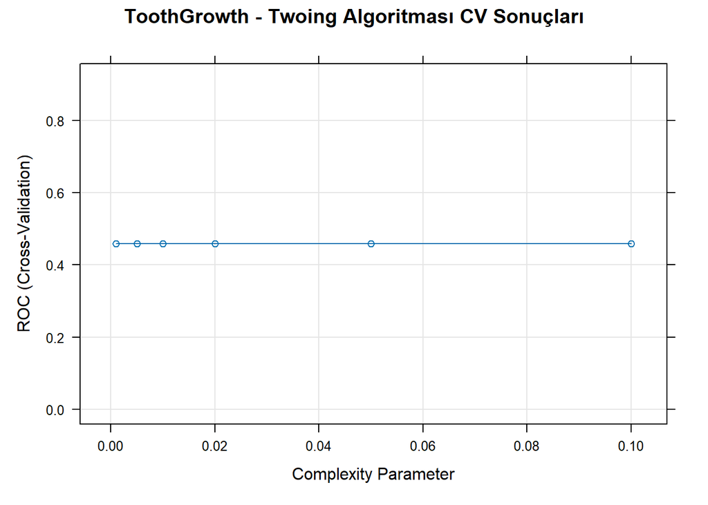

```r
# ROC grafiği
plot(model_tooth_twoing, main = "ToothGrowth - Twoing Algoritması CV Sonuçları")
```

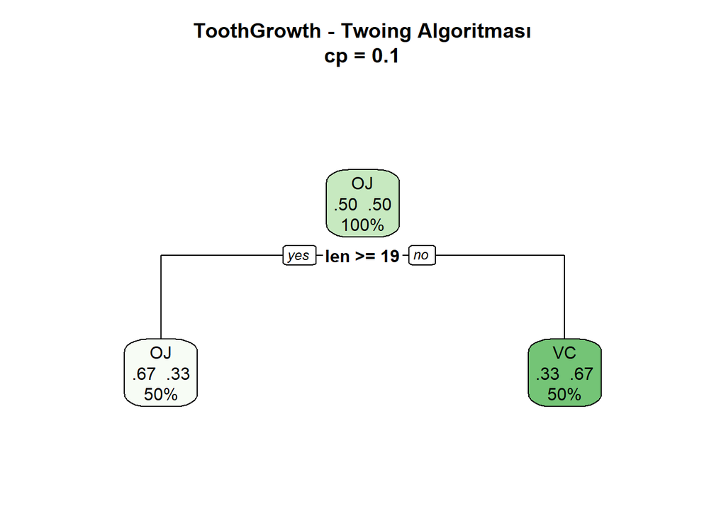

```r
final_tree <- model_tooth_twoing$finalModel
rpart.plot(
final_tree,
type = 2,
extra = 104,
fallen.leaves = TRUE,
main = paste("ToothGrowth - Twoing Algoritması\ncp =", model_tooth_twoing$bestTune$cp),
box.palette = "Greens"
)
```

```r
# Test setinde tahmin yap
test_pred <- predict(model_tooth_twoing, newdata = test_data)
# Confusion Matrix (Karışıklık Matrisi) oluştur
conf_matrix <- confusionMatrix(test_pred, test_data$supp, positive = "OJ")

print(conf_matrix)
```

```
## Confusion Matrix and Statistics
##
##           Reference
## Prediction OJ VC
##         OJ  3  1
##         VC  4  6
##
##                Accuracy : 0.6429
##                  95% CI : (0.3514, 0.8724)
##     No Information Rate : 0.5
##     P-Value [Acc > NIR] : 0.2120
##
##                   Kappa : 0.2857
##
##  Mcnemar's Test P-Value : 0.3711
##
##             Sensitivity : 0.4286
##             Specificity : 0.8571
##          Pos Pred Value : 0.7500
##          Neg Pred Value : 0.6000
##              Prevalence : 0.5000
##          Detection Rate : 0.2143
##    Detection Prevalence : 0.2857
##       Balanced Accuracy : 0.6429
##
##        'Positive' Class : OJ
##
```

### Bölüm 2- Mtcars Veri Seti

klasik mtcars veri seti kullanılarak bir aracın özelliklerine (beygir gücü, ağırlık, yakıt tüketimi vb.) bakarak şanzıman tipinin (Otomatik/Manuel) tahmin edilmesi amaçlanmıştır.

```r
library(caret)
data(mtcars)
df_mtcars <- mtcars
df_mtcars$am <- as.factor(df_mtcars$am)           # Hedef değişkeni faktör yap
levels(df_mtcars$am) <- c("Otomatik", "Manuel")
```

```r
set.seed(789)
index <- createDataPartition(df_mtcars$am, p = 0.75, list = FALSE)
train_data <- df_mtcars[index, ]
test_data <- df_mtcars[-index, ]

cat("\n=== VERİ BÖLÜNME SONUÇLARI ===\n")
```

```
##
## === VERİ BÖLÜNME SONUÇLARI ===
```

```r
cat("Eğitim seti:", nrow(train_data), "gözlem\n")
```

```
## Eğitim seti: 25 gözlem
```

```r
cat("Test seti:", nrow(test_data), "gözlem\n")
```

```
## Test seti: 7 gözlem
```

```r
cat("\nEğitim seti sınıf dağılımı:\n")
```

```
##
## Eğitim seti sınıf dağılımı:
```

```r
table(train_data$am)
```

```
##
## Otomatik   Manuel
##       15       10
```

```r
cat("\nTest seti sınıf dağılımı:\n")
```

```
##
## Test seti sınıf dağılımı:
```

```r
table(test_data$am)
```

```
##
## Otomatik   Manuel
##        4        3
```

```r
# Twoing algoritması ile model eğitimi (5-fold CV)
set.seed(456)
model_mtcars_twoing <- train(
  am ~ .,                                # Hedef: am, bağımsız: tüm değişkenler
  data = df_mtcars,                      # Tüm veri seti
  method = "rpart",
  trControl = control_class,             # Aynı CV ayarları
  tuneGrid = tune_grid,                  # Farklı cp değerleri
  parms = list(split = "twoing")         # Bölünme kriteri: TWOING
)
print(model_mtcars_twoing$results)
```

```
##      cp   ROC Sens Spec     ROCSD    SensSD    SpecSD
## 1 0.001 0.825 0.85  0.8 0.1677051 0.2236068 0.2738613
## 2 0.005 0.825 0.85  0.8 0.1677051 0.2236068 0.2738613
## 3 0.010 0.825 0.85  0.8 0.1677051 0.2236068 0.2738613
## 4 0.020 0.825 0.85  0.8 0.1677051 0.2236068 0.2738613
## 5 0.050 0.825 0.85  0.8 0.1677051 0.2236068 0.2738613
## 6 0.100 0.825 0.85  0.8 0.1677051 0.2236068 0.2738613
```

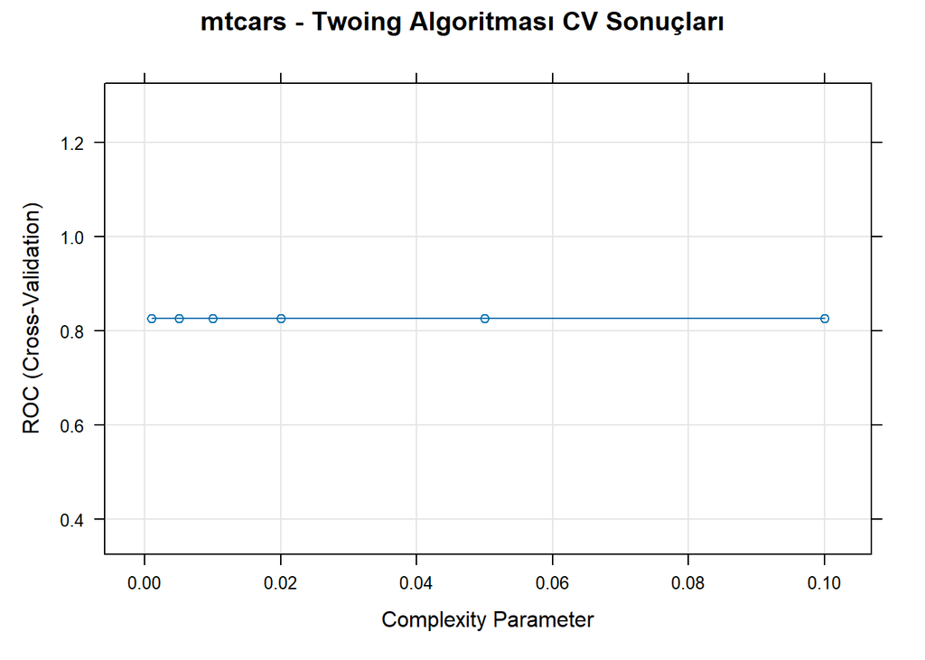

```r
# ROC grafiği
plot(model_mtcars_twoing, main = "mtcars - Twoing Algoritması CV Sonuçları")
```

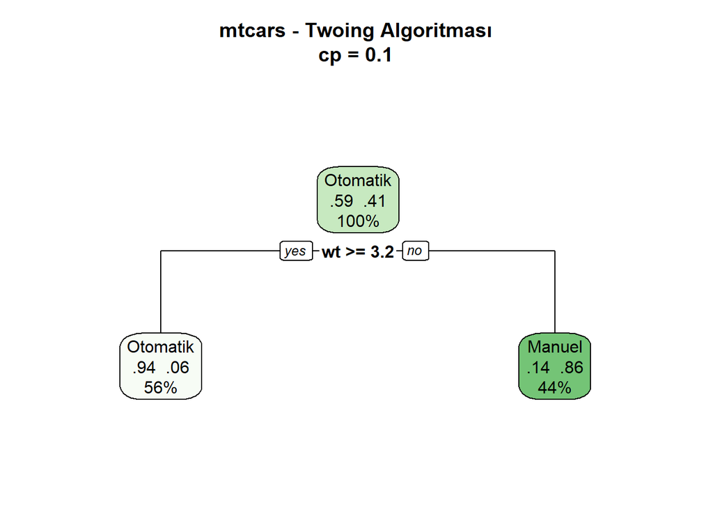

```r
# En iyi modelin karar ağacını görselleştir
final_tree_mtcars <- model_mtcars_twoing$finalModel

rpart.plot(final_tree_mtcars, type = 2, extra = 104,
main = paste("mtcars - Twoing Algoritması\ncp =", model_mtcars_twoing$bestTune$cp),
box.palette = "Greens", fallen.leaves = TRUE)
```

```r
# Test setinde tahmin yap
test_pred <- predict(model_mtcars_twoing, newdata = test_data)

# Confusion Matrix (Karışıklık Matrisi) oluştur
conf_matrix <- confusionMatrix(test_pred, test_data$am, positive = "Manuel")
print(conf_matrix)
```

```
## Confusion Matrix and Statistics
##
##           Reference
## Prediction Otomatik Manuel
##   Otomatik        4      0
##   Manuel          0      3
##
##                Accuracy : 1
##                  95% CI : (0.5904, 1)
##     No Information Rate : 0.5714
##     P-Value [Acc > NIR] : 0.01989
##
##                   Kappa : 1
##
##  Mcnemar's Test P-Value : NA
##
##             Sensitivity : 1.0000
##             Specificity : 1.0000
##          Pos Pred Value : 1.0000
##          Neg Pred Value : 1.0000
##              Prevalence : 0.4286
##          Detection Rate : 0.4286
##    Detection Prevalence : 0.4286
##       Balanced Accuracy : 1.0000
##
##        'Positive' Class : Manuel
##
```

### Bölüm 3-Titanik Veri Seti

```r
# titanic: Titanic veri seti için
# rpart: Karar ağacı algoritması (Twoing için)
# rpart.plot: Karar ağacını görselleştirme
# caret: Cross validation ve model değerlendirme için
# dplyr: Veri işleme için
library(titanic)
library(rpart)
library(rpart.plot)
library(caret)
library(dplyr)
```

#### 3.1 Veri Hazırlama ve Temizleme

```r
# Titanic veri setini yükle (titanic paketinden)
# titanic::titanic_train - eğitim için hazırlanmış Titanic verisi
mydata <- titanic::titanic_train

# Verinin yapısını incele
str(mydata)
```

```
## 'data.frame':    891 obs. of  12 variables:
##  $ PassengerId: int  1 2 3 4 5 6 7 8 9 10 ...
##  $ Survived   : int  0 1 1 1 0 0 0 0 1 1 ...
##  $ Pclass     : int  3 1 3 1 3 3 1 3 3 2 ...
##  $ Name       : chr  "Braund, Mr. Owen Harris" "Cumings, Mrs. John Bradley (Florence Briggs Thayer)" "Heikkinen, Miss. Laina" "Futrelle, Mrs. Jacques Heath (Lily May Peel)" ...
##  $ Sex        : chr  "male" "female" "female" "female" ...
##  $ Age        : num  22 38 26 35 35 NA 54 2 27 14 ...
##  $ SibSp      : int  1 1 0 1 0 0 0 3 0 1 ...
##  $ Parch      : int  0 0 0 0 0 0 0 1 2 0 ...
##  $ Ticket     : chr  "A/5 21171" "PC 17599" "STON/O2. 3101282" "113803" ...
##  $ Fare       : num  7.25 71.28 7.92 53.1 8.05 ...
##  $ Cabin      : chr  "" "C85" "" "C123" ...
##  $ Embarked   : chr  "S" "C" "S" "S" ...
```

```r
# Verinin ilk 6 satırını görüntüle
head(mydata)
```

```
##   PassengerId Survived Pclass
## 1           1        0      3
## 2           2        1      1
## 3           3        1      3
## 4           4        1      1
## 5           5        0      3
## 6           6        0      3
##                                                  Name    Sex Age SibSp Parch
## 1                             Braund, Mr. Owen Harris   male  22     1     0
## 2 Cumings, Mrs. John Bradley (Florence Briggs Thayer) female  38     1     0
## 3                              Heikkinen, Miss. Laina female  26     0     0
## 4        Futrelle, Mrs. Jacques Heath (Lily May Peel) female  35     1     0
## 5                            Allen, Mr. William Henry   male  35     0     0
## 6                                    Moran, Mr. James   male  NA     0     0
##             Ticket    Fare Cabin Embarked
## 1        A/5 21171  7.2500              S
## 2         PC 17599 71.2833   C85        C
## 3 STON/O2. 3101282  7.9250              S
## 4           113803 53.1000  C123        S
## 5           373450  8.0500              S
## 6           330877  8.4583              Q
```

```r
# Eksik verileri kontrol et
colSums(is.na(mydata))
```

```
## PassengerId    Survived      Pclass        Name         Sex         Age
##           0           0           0           0           0         177
##       SibSp       Parch      Ticket        Fare       Cabin    Embarked
##           0           0           0           0           0           0
```

```r
# Eksik verileri kaldır (NA - boş değer olan satırlar çıkarılır)
# na.omit() fonksiyonu herhangi bir sütunda NA olan satırları siler
mydata <- na.omit(mydata)
```

#### 3.2 Kategorik Değişkenleri Faktör Olarak Tanımla

```r
# Survived: Hayatta kalma durumu (0 = Hayır, 1 = Evet)
# Hedef değişken - tahmin etmek istediğimiz şey
# Twoing için faktör olmalı
mydata$Survived <- as.factor(mydata$Survived)
levels(mydata$Survived) <- c("No", "Yes")  # 0 = No, 1 = Yes

# Pclass: Yolcu sınıfı (1, 2, 3)
# 1. sınıf zenginler, 3. sınıf daha düşük gelirli yolcular
mydata$Pclass <- as.factor(mydata$Pclass)

# Sex: Cinsiyet (male, female) - Titanic'te kadınlar öncelikli kurtarıldı
mydata$Sex <- as.factor(mydata$Sex)

# Embarked: Biniş limanı (C = Cherbourg, Q = Queenstown, S = Southampton)
mydata$Embarked <- as.factor(mydata$Embarked)

# NOT: Age, SibSp, Parch, Fare sayısal değişken olarak kalır
# Twoing algoritması sayısal değişkenleri de işleyebilir

# Değişken tiplerini kontrol et
str(mydata)
```

```
## 'data.frame':    714 obs. of  12 variables:
##  $ PassengerId: int  1 2 3 4 5 7 8 9 10 11 ...
##  $ Survived   : Factor w/ 2 levels "No","Yes": 1 2 2 2 1 1 1 2 2 2 ...
##  $ Pclass     : Factor w/ 3 levels "1","2","3": 3 1 3 1 3 1 3 3 2 3 ...
##  $ Name       : chr  "Braund, Mr. Owen Harris" "Cumings, Mrs. John Bradley (Florence Briggs Thayer)" "Heikkinen, Miss. Laina" "Futrelle, Mrs. Jacques Heath (Lily May Peel)" ...
##  $ Sex        : Factor w/ 2 levels "female","male": 2 1 1 1 2 2 2 1 1 1 ...
##  $ Age        : num  22 38 26 35 35 54 2 27 14 4 ...
##  $ SibSp      : int  1 1 0 1 0 0 3 0 1 1 ...
##  $ Parch      : int  0 0 0 0 0 0 1 2 0 1 ...
##  $ Ticket     : chr  "A/5 21171" "PC 17599" "STON/O2. 3101282" "113803" ...
##  $ Fare       : num  7.25 71.28 7.92 53.1 8.05 ...
##  $ Cabin      : chr  "" "C85" "" "C123" ...
##  $ Embarked   : Factor w/ 4 levels "","C","Q","S": 4 2 4 4 4 4 4 4 2 4 ...
##  - attr(*, "na.action")= 'omit' Named int [1:177] 6 18 20 27 29 30 32 33 37 43 ...
##   ..- attr(*, "names")= chr [1:177] "6" "18" "20" "27" ...
```

```r
# Hedef değişken dağılımı
table(mydata$Survived)
```

```
##
##  No Yes
## 424 290
```

```r
prop.table(table(mydata$Survived)) * 100
```

```
##
##       No      Yes
## 59.38375 40.61625
```

#### 3.3 Eğitim ve Test Verilerini Ayırma

```r
set.seed(123)  # Sonuçların tekrarlanabilir olması için rastgelelik ayarı

# createDataPartition: Veriyi eğitim/test diye ayırır (sınıf oranlarını korur)
# Survived: Hedef değişken
# p = 0.8: %80 eğitim, %20 test
# list = FALSE: Sonuç indeks vektörü olarak dönsün
trainIndex <- createDataPartition(mydata$Survived, p = 0.8, list = FALSE)

# train_data: Seçilen satırlar (eğitim için)
train_data <- mydata[trainIndex, ]

# test_data: Seçilmeyen satırlar (test için)
test_data <- mydata[-trainIndex, ]

cat("\n=== VERİ BÖLÜNME SONUÇLARI ===\n")
```

```
##
## === VERİ BÖLÜNME SONUÇLARI ===
```

```r
cat("Eğitim seti:", nrow(train_data), "gözlem\n")
```

```
## Eğitim seti: 572 gözlem
```

```r
cat("Test seti:", nrow(test_data), "gözlem\n")
```

```
## Test seti: 142 gözlem
```

```r
# Sınıf dağılımlarını kontrol et
cat("\nEğitim seti sınıf dağılımı:\n")
```

```
##
## Eğitim seti sınıf dağılımı:
```

```r
table(train_data$Survived)
```

```
##
##  No Yes
## 340 232
```

```r
cat("\nTest seti sınıf dağılımı:\n")
```

```
##
## Test seti sınıf dağılımı:
```

```r
table(test_data$Survived)
```

```
##
##  No Yes
##  84  58
```

#### 3.5 Twoing ile Basit Model (CV’siz)

```r
# =====================================================
# 5.1 TWOING ALGORİTMASI - BASİT MODEL
# =====================================================
# Twoing algoritması ile model eğitimi
# parms = list(split = "twoing"): Bölünme kriteri olarak Twoing kullan
model_twoing <- rpart(
  Survived ~ Pclass + Sex + Age + SibSp + Parch + Fare + Embarked,
  data = train_data,
  method = "class",                      # Sınıflandırma problemi
  parms = list(split = "twoing"),        # TWOING bölünme kriteri
  control = rpart.control(
    cp = 0.01,                           # Karmaşıklık parametresi
    minsplit = 10,                       # Minimum bölünme gözlem sayısı
    minbucket = 5                        # Yaprak düğüm minimum gözlem
)
)
# Model özetini görüntüle
cat("\n=== TWOING MODELİ ÖZETİ ===\n")
```

```
##
## === TWOING MODELİ ÖZETİ ===
```

```r
print(model_twoing)
```

```
## n= 572
##
## node), split, n, loss, yval, (yprob)
##       * denotes terminal node
##
##  1) root 572 232 No (0.5944056 0.4055944)
##    2) Sex=male 355  71 No (0.8000000 0.2000000)
##      4) Pclass=2,3 285  43 No (0.8491228 0.1508772)
##        8) Age>=6.5 268  33 No (0.8768657 0.1231343) *
##        9) Age< 6.5 17   7 Yes (0.4117647 0.5882353)
##         18) SibSp>=2.5 8   1 No (0.8750000 0.1250000) *
##         19) SibSp< 2.5 9   0 Yes (0.0000000 1.0000000) *
##      5) Pclass=1 70  28 No (0.6000000 0.4000000)
##       10) Age>=36.5 45  13 No (0.7111111 0.2888889) *
##       11) Age< 36.5 25  10 Yes (0.4000000 0.6000000)
##         22) Age< 23.5 6   1 No (0.8333333 0.1666667) *
##         23) Age>=23.5 19   5 Yes (0.2631579 0.7368421) *
##    3) Sex=female 217  56 Yes (0.2580645 0.7419355)
##      6) Pclass=3 89  42 No (0.5280899 0.4719101)
##       12) Fare>=20.8 20   3 No (0.8500000 0.1500000) *
##       13) Fare< 20.8 69  30 Yes (0.4347826 0.5652174) *
##      7) Pclass=1,2 128   9 Yes (0.0703125 0.9296875) *
```

```r
# Değişken önem dereceleri
cat("\n=== DEĞİŞKEN ÖNEM DERECELERİ ===\n")
```

```
##
## === DEĞİŞKEN ÖNEM DERECELERİ ===
```

```r
print(model_twoing$variable.importance)
```

```
##       Sex      Fare    Pclass       Age     Parch     SibSp  Embarked
## 79.107422 34.428715 31.410273 23.950926 17.042065 12.814120  5.409291
```

#### 3.6 Twoing ile Cross Validation (LOOCV )

```r
# Not: Titanic verisi 700+ gözlem olduğu için 5-fold veya 10-fold kullanılabilir
# Ancak küçük veri setlerinde olduğu gibi LOOCV da uygulanabilir
# LOOCV ayarları
set.seed(123)
control_loocv <- trainControl(
method = "LOOCV",                      # Leave-One-Out Cross Validation
classProbs = TRUE,
summaryFunction = twoClassSummary,
savePredictions = TRUE
)

# Farklı cp değerleri
tune_grid <- expand.grid(cp = c(0.001, 0.005, 0.01, 0.02, 0.05, 0.1))

# Twoing ile model eğitimi (LOOCV)
model_twoing_loocv <- train(
Survived ~ Pclass + Sex + Age + SibSp + Parch + Fare + Embarked,
data = train_data,
method = "rpart",
trControl = control_loocv,
tuneGrid = tune_grid,
parms = list(split = "twoing"),
metric = "ROC"
)

print(model_twoing_loocv)
```

```
## CART
##
## 572 samples
##   7 predictor
##   2 classes: 'No', 'Yes'
##
## No pre-processing
## Resampling: Leave-One-Out Cross-Validation
## Summary of sample sizes: 571, 571, 571, 571, 571, 571, ...
## Resampling results across tuning parameters:
##
##   cp     ROC        Sens       Spec
##   0.001  0.7845588  0.8352941  0.7025862
##   0.005  0.7880198  0.8382353  0.6853448
##   0.010  0.7974772  0.8235294  0.6810345
##   0.020  0.6634762  0.8852941  0.6810345
##   0.050  0.5796653  0.8352941  0.6939655
##   0.100  0.5796653  0.8352941  0.6939655
##
## ROC was used to select the optimal model using the largest value.
## The final value used for the model was cp = 0.01.
```

#### 3.7 Twoing ile 10-Fold Cross Validation

```r
# 10-fold CV ayarları
set.seed(123)
control_10fold <- trainControl(
method = "cv",                         # Cross validation
number = 10,                           # 10 kat
classProbs = TRUE,
summaryFunction = twoClassSummary,
savePredictions = TRUE
)

# Twoing ile model eğitimi (10-fold CV)
model_twoing_10fold <- train(
Survived ~ Pclass + Sex + Age + SibSp + Parch + Fare + Embarked,
data = train_data,
method = "rpart",
trControl = control_10fold,
tuneGrid = tune_grid,
parms = list(split = "twoing"),
metric = "ROC"
)

print(model_twoing_10fold)
```

```
## CART
##
## 572 samples
##   7 predictor
##   2 classes: 'No', 'Yes'
##
## No pre-processing
## Resampling: Cross-Validated (10 fold)
## Summary of sample sizes: 515, 515, 515, 515, 515, 515, ...
## Resampling results across tuning parameters:
##
##   cp     ROC        Sens       Spec
##   0.001  0.8397618  0.8529412  0.6643116
##   0.005  0.8413443  0.8323529  0.6858696
##   0.010  0.8326673  0.8735294  0.6382246
##   0.020  0.8057678  0.8823529  0.6594203
##   0.050  0.7647485  0.8352941  0.6942029
##   0.100  0.7647485  0.8352941  0.6942029
##
## ROC was used to select the optimal model using the largest value.
## The final value used for the model was cp = 0.005.
```

```r
# Her fold'un performansı
print(model_twoing_10fold$resample)
```

```
##          ROC      Sens      Spec Resample
## 1  0.7410486 0.7647059 0.6521739   Fold09
## 2  0.9130435 0.9117647 0.8260870   Fold05
## 3  0.8171355 0.7941176 0.7391304   Fold03
## 4  0.7781330 0.9117647 0.5217391   Fold01
## 5  0.8400735 0.7941176 0.6250000   Fold07
## 6  0.8860294 0.9117647 0.6250000   Fold10
## 7  0.8497442 0.8823529 0.6956522   Fold08
## 8  0.8938619 0.8529412 0.6956522   Fold06
## 9  0.8823529 0.7058824 0.7826087   Fold04
## 10 0.8120205 0.7941176 0.6956522   Fold02
```

Modelimi 10 katlı çapraz geçerlilikle zorlu testlerden geçirdim ve performansı bu şekildeydi

#### 3.8 KARAR AĞACINI GÖRSELLEŞTİRME

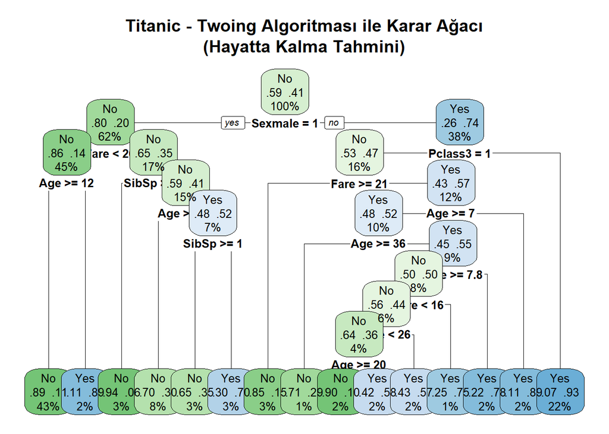

```r
# En iyi modeli seç (10-fold CV ile eğitilen)
best_model <- model_twoing_10fold$finalModel

# Karar ağacını görselleştir
rpart.plot(
  best_model,
  type = 2,                # Düğüm içi etiket stili
  extra = 104,             # Sınıf ve yüzde gösterimi
  fallen.leaves = TRUE,    # Yaprakları aynı hizaya getir
  main = "Titanic - Twoing Algoritması ile Karar Ağacı\n(Hayatta Kalma Tahmini)",
  box.palette = "GnBu",              # Renk paleti
  cex = 0.8
)
```

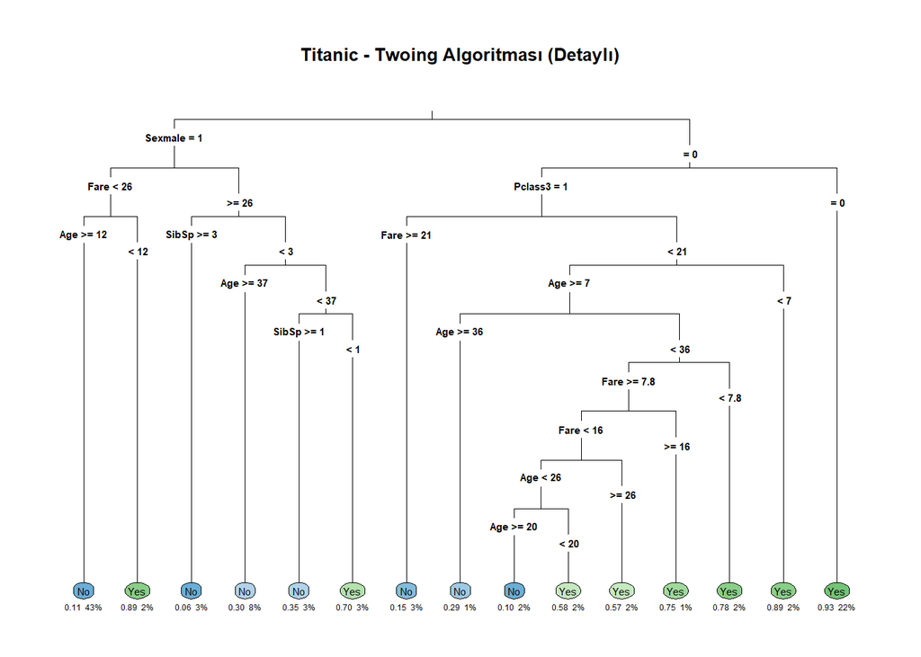

```r
# Alternatif görselleştirme (daha detaylı)
rpart.plot(
  best_model,
  type = 3,
  extra = 106,
  under = TRUE,
  main = "Titanic - Twoing Algoritması (Detaylı)",
  box.palette = "auto"
)
```

#### 3.9 Değerlendirme

```r
# Test setinde tahmin yap
test_pred <- predict(model_twoing_10fold, newdata = test_data)

# Confusion Matrix (Karışıklık Matrisi) oluştur
conf_matrix <- confusionMatrix(test_pred, test_data$Survived, positive = "Yes")

print(conf_matrix)
```

```
## Confusion Matrix and Statistics
##
##           Reference
## Prediction No Yes
##        No  71  11
##        Yes 13  47
##
##                Accuracy : 0.831
##                  95% CI : (0.759, 0.8886)
##     No Information Rate : 0.5915
##     P-Value [Acc > NIR] : 7.518e-10
##
##                   Kappa : 0.6521
##
##  Mcnemar's Test P-Value : 0.8383
##
##             Sensitivity : 0.8103
##             Specificity : 0.8452
##          Pos Pred Value : 0.7833
##          Neg Pred Value : 0.8659
##              Prevalence : 0.4085
##          Detection Rate : 0.3310
##    Detection Prevalence : 0.4225
##       Balanced Accuracy : 0.8278
##
##        'Positive' Class : Yes
##
```